# Exercice 4

Wilson FOTSING

2025-04-06

# Tâche 1 : Réflexion

En analyse de données, la représentation visuelle des comptes et des proportions joue un rôle fondamental pour faciliter la compréhension et la communication des résultats.

Bien que les diagrammes à barres ou les camemberts sont largement utilisés, ils ne sont pas toujours les plus appropriés selon le contexte. il y a des bonnes pratiques qu’il faut utiliser et des mauvaises pratiques à éviter.

1- Toujours commencer les barres à zéro pour éviter les biais visuels ;

2- Éviter les barres pour des statistiques descriptives continues (ex. moyennes) ;

3- Prioriser les diagrammes en barres au détriment des diagrammes circulaire ;

4- Il est douvent recommandé de mettre des points aléatoires (jitter plots) avec geom_point()

5- Même si on utilise des Boxplots ou des violentPlots pour visualiser, il est aussi parfois necessaire d’ajouter les points sur le graphiques pour capturer la distribution des points

# Tâche 2 : Construction pandémique essentielle

## Charger et nettoyer les données

```r
library(tidyverse)
essential_raw <- read_csv("data/EssentialConstruction.csv")

# Nettoyage des données
essentiel <- essential_raw %>%
  mutate(
    ARRONDISSEMENT = str_to_title(BOROUGH),
    ARRONDISSEMENT = factor(ARRONDISSEMENT),
    CATÉGORIE = factor(CATEGORY)
  )
```

## Projets approuvés par arrondissement

À l’heure actuelle, il y a une ligne pour chaque chantier de construction approuvé. Nous devons condenser cela pour obtenir le nombre de chantiers de construction selon différentes variables. Nous pouvons le faire en utilisant `group_by()` et `summarize()`

```r
essentiel_par_arrondissement <- essentiel %>%
  group_by(ARRONDISSEMENT) %>%
  summarise(total = n()) %>%
  mutate(proportion = total / sum(total))

essentiel_par_arrondissement
```

```
## # A tibble: 5 × 3
##   ARRONDISSEMENT total proportion
##   <fct>          <int>      <dbl>
## 1 Bronx           1287     0.156
## 2 Brooklyn        2610     0.317
## 3 Manhattan       2665     0.323
## 4 Queens          1395     0.169
## 5 Staten Island    286     0.0347
```

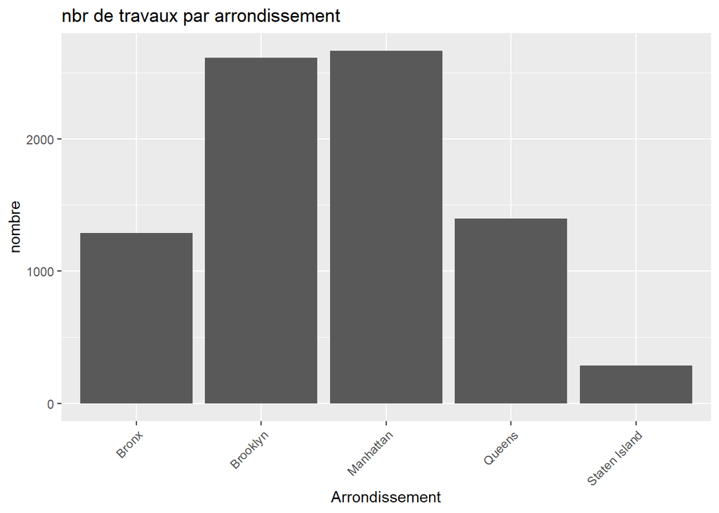

```r
# Ajouter un graphique avec geom_col() ici
ggplot(essentiel_par_arrondissement, aes(x = ARRONDISSEMENT, y = total)) +
  geom_col() +
  labs(title = "nbr de travaux par arrondissement", x = "Arrondissement", y = "nombre") +
  theme(axis.text.x = element_text(angle = 45, hjust = 1))
```

## Projets approuvés par catégorie

```r
# Créer un jeu de données résumé des projets par catégorie
essentiel_par_categorie <- essentiel %>%
  group_by(CATEGORY) %>%
  summarise(total = n()) %>%
  mutate(proportion = total / sum(total))

essentiel_par_categorie
```

```
## # A tibble: 7 × 3
##   CATEGORY               total proportion
##   <chr>                  <int>      <dbl>
## 1 Affordable Housing       379   0.0460
## 2 Approved Work           5131   0.622
## 3 Homeless Shelter           5   0.000607
## 4 Hospital / Health Care   287   0.0348
## 5 Public Housing          1045   0.127
## 6 Schools                 1298   0.157
## 7 Utility                   98   0.0119
```

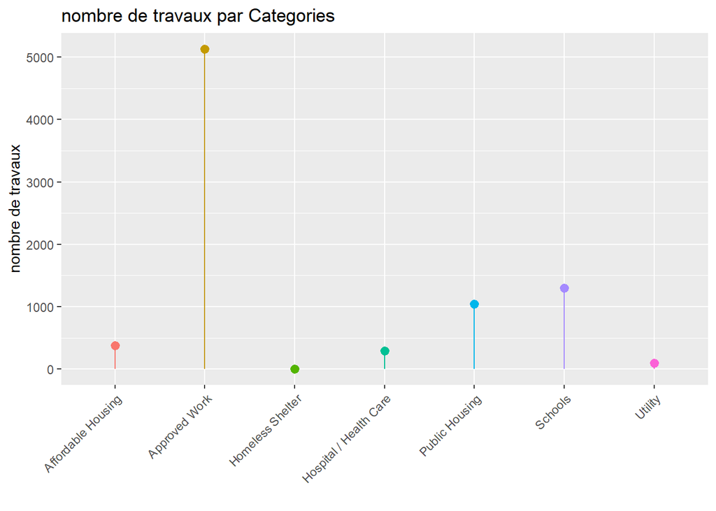

```r
# Ajoutez un graphique en forme de sucette (lollipop) ici
ggplot(essentiel_par_categorie, aes(x = CATEGORY, y = total,color = CATEGORY)) +
  geom_pointrange(aes(ymin = 0, ymax = total)) +
  guides(color = "none") +
  labs(title = "nombre de travaux par Categories", x = " ", y = "nombre de travaux") +
  theme(axis.text.x = element_text(angle = 45, hjust = 1)) +
  scale_fill_viridis_d()
```

## Projets approuvés dans l’arrondissement et la catégorie

```r
# Créer un ensemble de données résumé des projets par arrondissement et par catégorie

projets_par_arr_cat <- essentiel %>%
  group_by(ARRONDISSEMENT, CATEGORY) %>%
  summarise(nombre_de_projets = n(), .groups = "drop") %>%
  group_by(ARRONDISSEMENT) %>%
  mutate(proportion = nombre_de_projets / sum(nombre_de_projets))

# Afficher le résultat
print(projets_par_arr_cat)
```

```
## # A tibble: 33 × 4
## # Groups:   ARRONDISSEMENT [5]
##    ARRONDISSEMENT CATEGORY               nombre_de_projets proportion
##    <fct>          <chr>                              <int>      <dbl>
##  1 Bronx          Affordable Housing                    80   0.0622
##  2 Bronx          Approved Work                        627   0.487
##  3 Bronx          Homeless Shelter                       1   0.000777
##  4 Bronx          Hospital / Health Care                56   0.0435
##  5 Bronx          Public Housing                       278   0.216
##  6 Bronx          Schools                              235   0.183
##  7 Bronx          Utility                               10   0.00777
##  8 Brooklyn       Affordable Housing                   170   0.0651
##  9 Brooklyn       Approved Work                       1567   0.600
## 10 Brooklyn       Hospital / Health Care                71   0.0272
## # ℹ 23 more rows
```

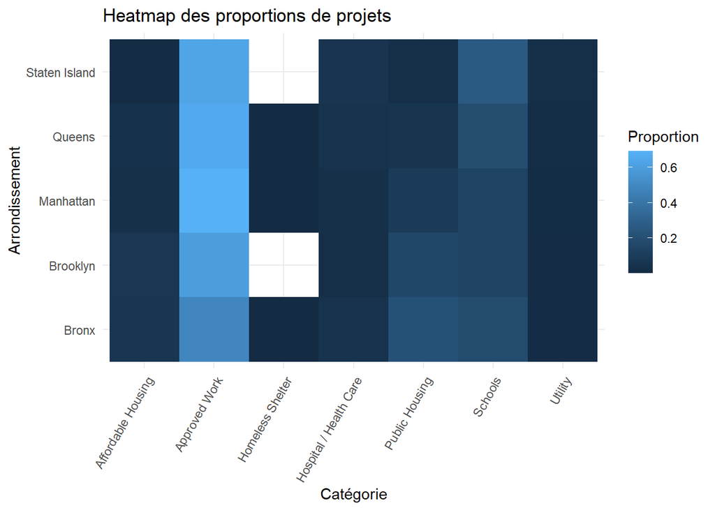

```r
# Ajoutez une heatmap ici avec geom_tile()

ggplot(projets_par_arr_cat, aes(x = CATEGORY, y = ARRONDISSEMENT, fill = proportion)) +
  geom_tile() +
  labs(title = "Heatmap des proportions de projets",
       x = "Catégorie",
       y = "Arrondissement",
       fill = "Proportion") +
  theme_minimal() +
  theme(axis.text.x = element_text(angle = 60, hjust = 1))
```